# Tugas Pertemuan 2 - Metode Peramalan Deret Waktu

## Library/Packages

```r
library(readxl)
library(forecast)
library(TTR)
library(ggplot2)
```

## Deskripsi Data

Data yang digunakan adalah jumlah pegawai pemerintah daerah di sektor pendidikan (CES9093161101, sumber BLS via FRED, satuan ribuan orang, seasonally adjusted), bagian saya yaitu periode ke 683-852 dari data kelompok (170 observasi, Nov 2011 - Des 2025, bulanan).

## Impor Data

```r
raw <- read_excel("CES9093161101.xlsx", sheet = "Monthly")
bagian <- raw[683:852, ]
bagian$Periode <- 1:nrow(bagian)
head(bagian)
```

```
## # A tibble: 6 × 4
##   observation_date    Period CES9093161101 Periode
##   <dttm>               <dbl>         <dbl>   <int>
## 1 2011-11-01 00:00:00    683         7815.       1
## 2 2011-12-01 00:00:00    684         7804.       2
## 3 2012-01-01 00:00:00    685         7797.       3
## 4 2012-02-01 00:00:00    686         7800.       4
## 5 2012-03-01 00:00:00    687         7794.       5
## 6 2012-04-01 00:00:00    688         7786.       6
```

## Eksplorasi Data

```r
str(bagian)
```

```
## tibble [170 × 4] (S3: tbl_df/tbl/data.frame)
##  $ observation_date: POSIXct[1:170], format: "2011-11-01" "2011-12-01" ...
##  $ Period          : num [1:170] 683 684 685 686 687 688 689 690 691 692 ...
##  $ CES9093161101   : num [1:170] 7815 7804 7797 7800 7794 ...
##  $ Periode         : int [1:170] 1 2 3 4 5 6 7 8 9 10 ...
```

```r
dim(bagian)
```

```
## [1] 170   4
```

```r
full.ts <- ts(bagian$CES9093161101, start = c(2011, 11), frequency = 12)
summary(full.ts)
```

```
##    Min. 1st Qu.  Median    Mean 3rd Qu.    Max.
##    7328    7774    7892    7881    7986    8240
```

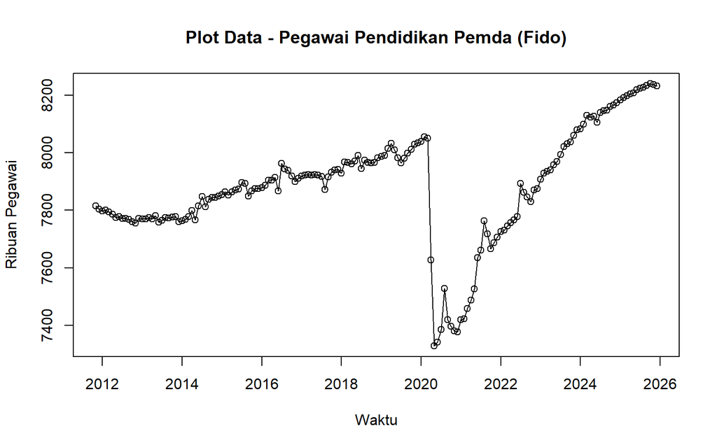

```r
ts.plot(full.ts, xlab = "Waktu", ylab = "Ribuan Pegawai",
        main = "Plot Data - Pegawai Pendidikan Pemda (Fido)")
points(full.ts)
```

Data menunjukkan pola tren naik tanpa pola musiman yang jelas. Ini wajar karena data sudah *seasonally adjusted* oleh BLS sebelum dipublikasikan, sehingga efek musiman aslinya sudah dihilangkan di sumbernya.

## Pembagian Data (80% Latih, 20% Uji)

```r
n <- length(full.ts)
n_train <- floor(0.8 * n)
n_test <- n - n_train

# window() dipakai (bukan slice+re-ts) supaya tanggal bulanan tetap konsisten
train.ts <- window(full.ts, end = time(full.ts)[n_train])
test.ts  <- window(full.ts, start = time(full.ts)[n_train + 1])

training <- bagian[1:n_train, ]
testing  <- bagian[(n_train + 1):n, ]

n_train
```

```
## [1] 136
```

```r
n_test
```

```
## [1] 34
```

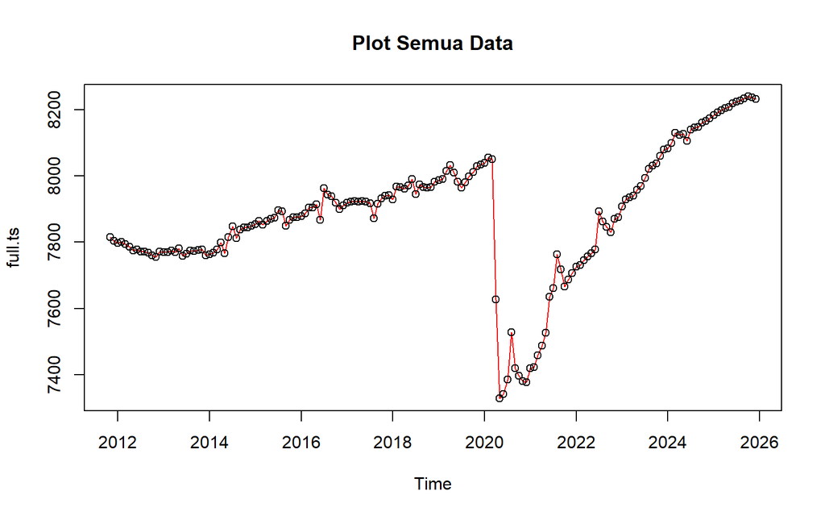

```r
plot(full.ts, col = "red", main = "Plot Semua Data")
points(full.ts)
```

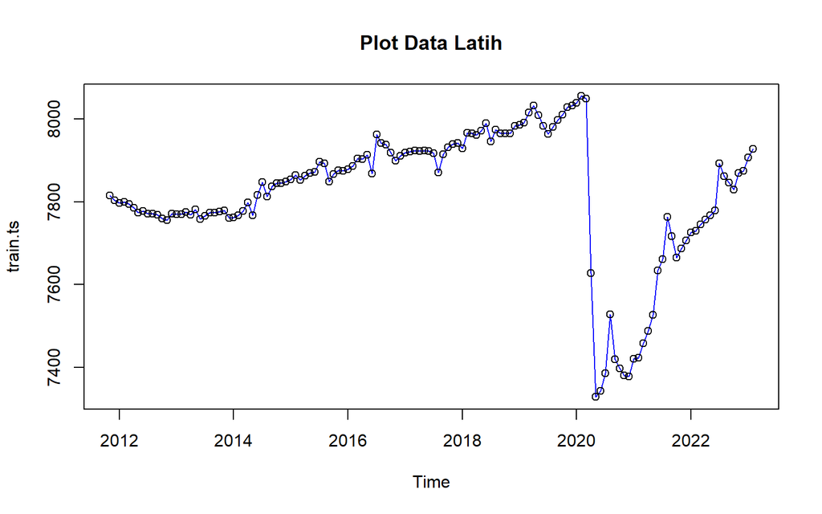

```r
plot(train.ts, col = "blue", main = "Plot Data Latih")
points(train.ts)
```

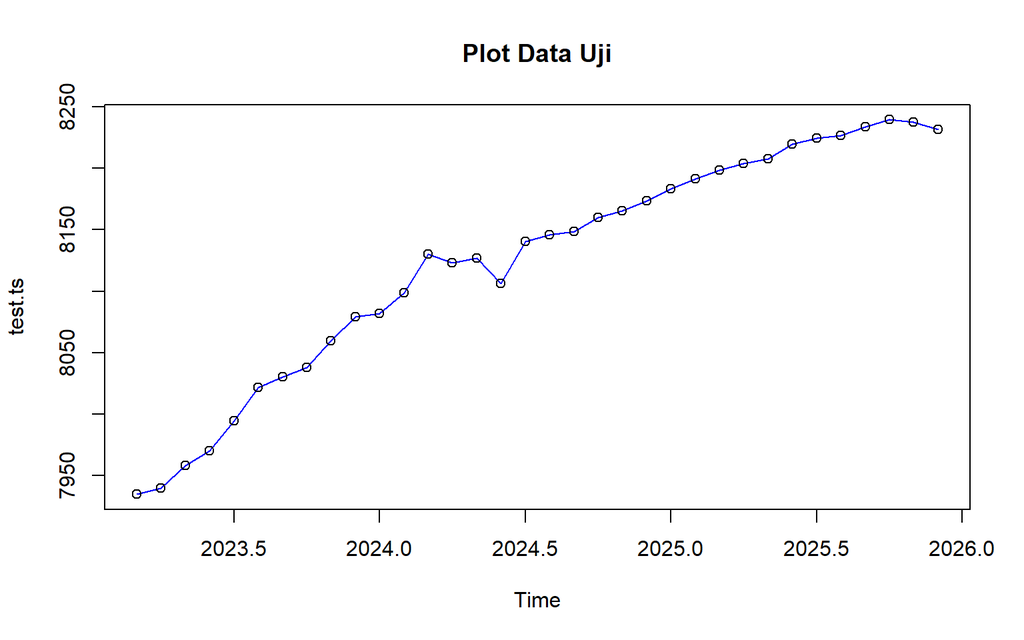

```r
plot(test.ts, col = "blue", main = "Plot Data Uji")
points(test.ts)
```

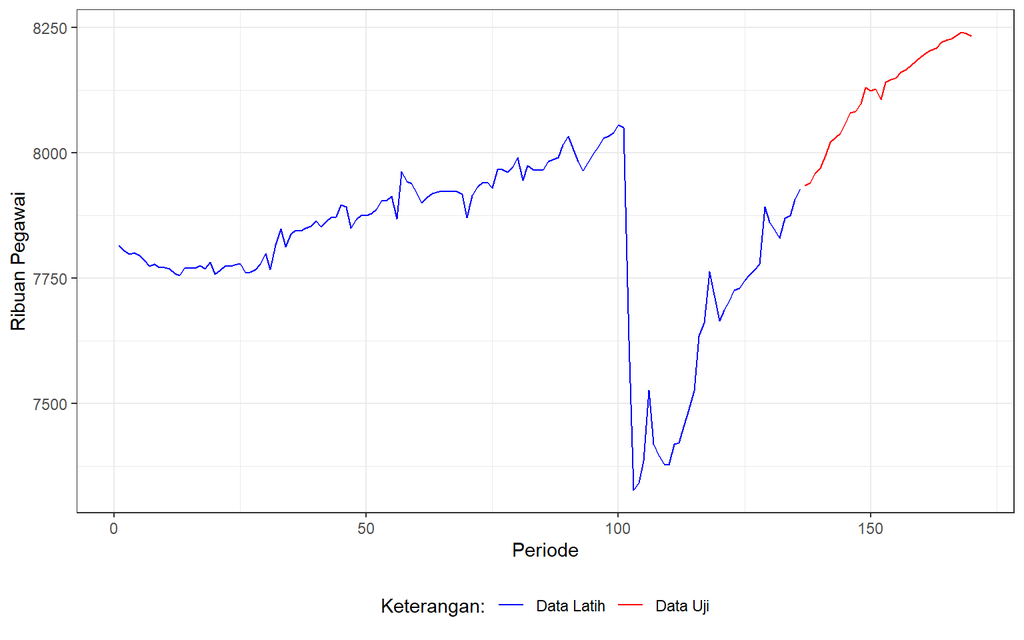

```r
ggplot() +
  geom_line(data = training, aes(x = Periode, y = CES9093161101, col = "Data Latih")) +
  geom_line(data = testing, aes(x = Periode, y = CES9093161101, col = "Data Uji")) +
  labs(x = "Periode", y = "Ribuan Pegawai", color = "Legend") +
  scale_colour_manual(name = "Keterangan:", breaks = c("Data Latih", "Data Uji"),
                       values = c("blue", "red")) +
  theme_bw() + theme(legend.position = "bottom")
```

## Fungsi Akurasi

Dipakai konsisten untuk semua metode, mengabaikan pasangan actual-ramalan yang NA.

```r
akurasi <- function(actual, ramalan) {
  e <- actual - ramalan
  valid <- !is.na(e) & !is.na(actual)
  e <- e[valid]; a <- actual[valid]
  c(SSE = sum(e^2), MSE = mean(e^2), RMSE = sqrt(mean(e^2)), MAPE = mean(abs(e / a)) * 100)
}
```

## Single Moving Average (SMA)

```r
m_list <- 2:12
hasil <- sapply(m_list, function(m) {
  sma_val <- SMA(train.ts, n = m)
  fitted_sma <- c(NA, sma_val[-n_train])
  akurasi(as.numeric(train.ts), fitted_sma)["RMSE"]
})
names(hasil) <- m_list
hasil
```

```
##         2         3         4         5         6         7         8         9
##  67.41143  77.88025  85.61309  91.84849  98.22139 104.59716 110.93602 116.94933
##        10        11        12
## 122.57237 128.01686 133.37285
```

```r
which.min(hasil)
```

```
## 2
## 1
```

Orde m = 2 dipakai berdasarkan hasil trial-and-error (RMSE minimum di antara m = 2 sampai 12).

```r
m <- 2
data.sma <- SMA(train.ts, n = m)
data.ramal <- c(NA, data.sma)

h <- n_test
forecast.sma <- rep(data.ramal[length(data.ramal)], h)

data.gab.sma <- cbind(
  aktual = as.numeric(full.ts),
  pemulusan = c(data.sma, rep(NA, h)),
  ramalan = c(data.ramal, rep(forecast.sma[1], h - 1))
)
```

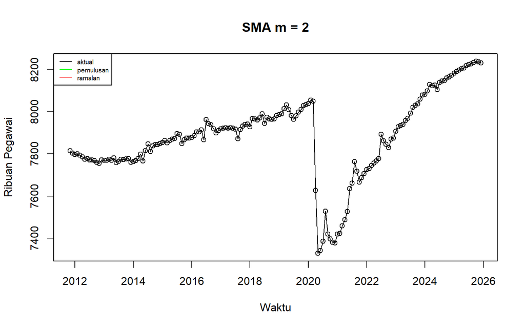

```r
ts.plot(full.ts, xlab = "Waktu", ylab = "Ribuan Pegawai", main = paste("SMA m =", m))
points(full.ts)
lines(data.gab.sma[, "pemulusan"], col = "green", lwd = 2)
lines(data.gab.sma[, "ramalan"], col = "red", lwd = 2)
legend("topleft", c("aktual", "pemulusan", "ramalan"),
       col = c("black", "green", "red"), lty = 1, cex = 0.6)
```

### Akurasi Data Latih

```r
acc_train_sma <- akurasi(as.numeric(train.ts)[(m + 1):n_train], data.ramal[(m + 1):n_train])
acc_train_sma
```

```
##          SSE          MSE         RMSE         MAPE
## 6.089363e+05 4.544300e+03 6.741143e+01 3.823145e-01
```

### Akurasi Data Uji

```r
idx_test <- (n_train + 1):n
acc_test_sma <- akurasi(as.numeric(test.ts), data.gab.sma[idx_test, "ramalan"])
acc_test_sma
```

```
##          SSE          MSE         RMSE         MAPE
## 1.742395e+06 5.124692e+04 2.263778e+02 2.533836e+00
```

## Double Moving Average (DMA)

```r
s1 <- SMA(train.ts, n = m)
s2 <- SMA(s1, n = m)
At <- 2 * s1 - s2
Bt <- (2 / (m - 1)) * (s1 - s2)

data.dma <- At + Bt
data.ramal2 <- c(NA, data.dma)

t_ahead <- 1:h
f <- At[length(At)] + Bt[length(Bt)] * t_ahead

data.gab.dma <- cbind(
  aktual = as.numeric(full.ts),
  pemulusan1 = c(s1, rep(NA, h)),
  pemulusan2 = c(s2, rep(NA, h)),
  ramalan = c(data.ramal2, f[-1])
)
```

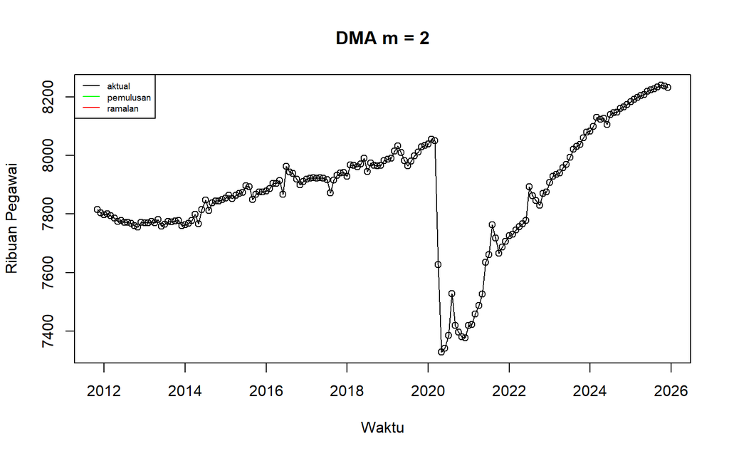

```r
ts.plot(full.ts, xlab = "Waktu", ylab = "Ribuan Pegawai", main = paste("DMA m =", m))
points(full.ts)
lines(data.gab.dma[, "pemulusan2"], col = "green", lwd = 2)
lines(data.gab.dma[, "ramalan"], col = "red", lwd = 2)
legend("topleft", c("aktual", "pemulusan", "ramalan"),
       col = c("black", "green", "red"), lty = 1, cex = 0.6)
```

### Akurasi Data Latih

```r
start_idx <- 2 * m
acc_train_dma <- akurasi(as.numeric(train.ts)[start_idx:n_train], data.ramal2[start_idx:n_train])
acc_train_dma
```

```
##          SSE          MSE         RMSE         MAPE
## 6.528259e+05 4.908466e+03 7.006044e+01 4.387752e-01
```

### Akurasi Data Uji

```r
acc_test_dma <- akurasi(as.numeric(test.ts), data.gab.dma[idx_test, "ramalan"])
acc_test_dma
```

```
##          SSE          MSE         RMSE         MAPE
## 3.376256e+06 9.930166e+04 3.151217e+02 3.247785e+00
```

## Single Exponential Smoothing (SES)

Parameter alpha dioptimalkan otomatis (bukan diset manual) lewat `ses()`.

```r
ses_fit <- ses(train.ts, h = h)
ses_fit$model
```

```
## Simple exponential smoothing
##
## Call:
## ses(y = train.ts, h = h)
##
##   Smoothing parameters:
##     alpha = 0.9999
##
##   Initial states:
##     l = 7814.7597
##
##   sigma:  54.2088
##
##      AIC     AICc      BIC
## 1758.159 1758.341 1766.897
```

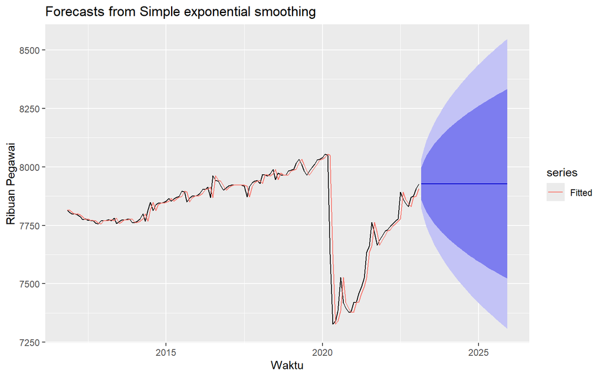

```r
autoplot(ses_fit) +
  autolayer(fitted(ses_fit), series = "Fitted") +
  ylab("Ribuan Pegawai") + xlab("Waktu")
```

### Akurasi Data Latih

```r
acc_train_ses <- akurasi(as.numeric(train.ts), as.numeric(fitted(ses_fit)))
acc_train_ses
```

```
##          SSE          MSE         RMSE         MAPE
## 3.937710e+05 2.895375e+03 5.380869e+01 3.127175e-01
```

### Akurasi Data Uji

```r
acc_test_ses <- akurasi(as.numeric(test.ts), as.numeric(ses_fit$mean))
acc_test_ses
```

```
##          SSE          MSE         RMSE         MAPE
## 1.598462e+06 4.701359e+04 2.168262e+02 2.404603e+00
```

## Double Exponential Smoothing / Holt (DES)

Menangkap level sekaligus tren, alpha dan beta dioptimalkan otomatis lewat `holt()`.

```r
des_fit <- holt(train.ts, h = h)
des_fit$model
```

```
## Holt's method
##
## Call:
## holt(y = train.ts, h = h)
##
##   Smoothing parameters:
##     alpha = 0.9988
##     beta  = 1e-04
##
##   Initial states:
##     l = 7815.873
##     b = 0.7209
##
##   sigma:  54.6324
##
##      AIC     AICc      BIC
## 1762.232 1762.693 1776.795
```

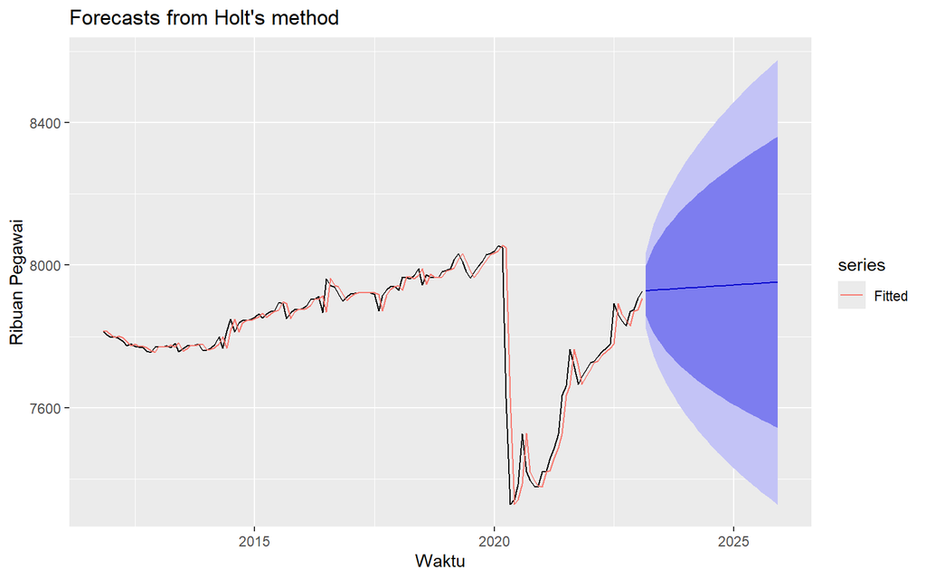

```r
autoplot(des_fit) +
  autolayer(fitted(des_fit), series = "Fitted") +
  ylab("Ribuan Pegawai") + xlab("Waktu")
```

### Akurasi Data Latih

```r
acc_train_des <- akurasi(as.numeric(train.ts), as.numeric(fitted(des_fit)))
acc_train_des
```

```
##          SSE          MSE         RMSE         MAPE
## 3.939803e+05 2.896914e+03 5.382299e+01 3.110804e-01
```

### Akurasi Data Uji

```r
acc_test_des <- akurasi(as.numeric(test.ts), as.numeric(des_fit$mean))
acc_test_des
```

```
##          SSE          MSE         RMSE         MAPE
## 1.394012e+06 4.100035e+04 2.024854e+02 2.250224e+00
```

## Holt-Winters

Disertakan untuk melengkapi instruksi tugas, meski komponen musimannya diperkirakan kurang bermakna karena data sumber sudah *seasonally adjusted* (lihat bagian Eksplorasi Data).

```r
hw_fit <- HoltWinters(train.ts)
hw_forecast <- forecast(hw_fit, h = h)
```

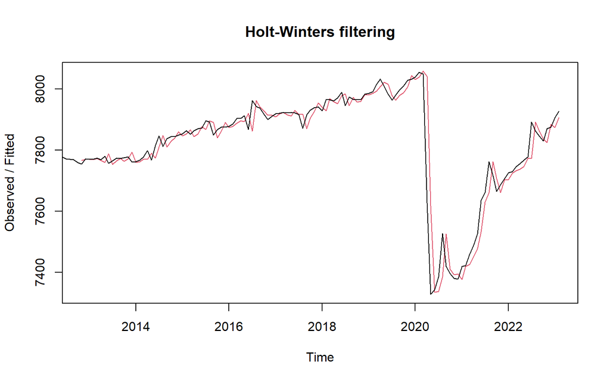

```r
plot(hw_fit)
```

### Akurasi Data Latih

```r
train_hw_actual <- window(train.ts, start = start(fitted(hw_fit)))
acc_train_hw <- akurasi(as.numeric(train_hw_actual), as.numeric(fitted(hw_fit)[, "xhat"]))
acc_train_hw
```

```
##          SSE          MSE         RMSE         MAPE
## 3.876168e+05 3.125942e+03 5.591012e+01 3.525913e-01
```

### Akurasi Data Uji

```r
acc_test_hw <- akurasi(as.numeric(test.ts), as.numeric(hw_forecast$mean))
acc_test_hw
```

```
##          SSE          MSE         RMSE         MAPE
## 2.041778e+06 6.005230e+04 2.450557e+02 2.718395e+00
```

## Perbandingan Metode & Kesimpulan

```r
tabel <- rbind(
  SMA          = c(acc_train_sma, acc_test_sma),
  DMA          = c(acc_train_dma, acc_test_dma),
  SES          = c(acc_train_ses, acc_test_ses),
  DES          = c(acc_train_des, acc_test_des),
  `Holt-Winters` = c(acc_train_hw, acc_test_hw)
)
colnames(tabel) <- c("SSE_Latih", "MSE_Latih", "RMSE_Latih", "MAPE_Latih",
                      "SSE_Uji", "MSE_Uji", "RMSE_Uji", "MAPE_Uji")
tabel <- round(tabel, 3)
knitr::kable(tabel)
```

|  | SSE_Latih | MSE_Latih | RMSE_Latih | MAPE_Latih | SSE_Uji | MSE_Uji | RMSE_Uji | MAPE_Uji |
| --- | --- | --- | --- | --- | --- | --- | --- | --- |
| SMA | 608936.3 | 4544.300 | 67.411 | 0.382 | 1742395 | 51246.92 | 226.378 | 2.534 |
| DMA | 652825.9 | 4908.466 | 70.060 | 0.439 | 3376256 | 99301.66 | 315.122 | 3.248 |
| SES | 393771.0 | 2895.375 | 53.809 | 0.313 | 1598462 | 47013.59 | 216.826 | 2.405 |
| DES | 393980.3 | 2896.914 | 53.823 | 0.311 | 1394012 | 41000.36 | 202.485 | 2.250 |
| Holt-Winters | 387616.8 | 3125.942 | 55.910 | 0.353 | 2041778 | 60052.30 | 245.056 | 2.718 |

```r
terbaik <- rownames(tabel)[which.min(tabel[, "MAPE_Uji"])]
terbaik
```

```
## [1] "DES"
```

Metode terbaik dipilih berdasarkan **MAPE data uji** terkecil, karena MAPE scale-free (adil dibandingkan antar metode) dan data uji mengukur kemampuan generalisasi ke data yang tidak dipakai fitting, bukan sekadar kecocokan terhadap data latih.

Berdasarkan tabel di atas, metode terbaik untuk data ini adalah **DES**. Holt-Winters diperkirakan tidak unggul karena data sumber sudah seasonally adjusted, sehingga komponen musiman yang coba ditangkapnya tidak punya banyak sinyal nyata untuk dipelajari.